# Reproducible Research: Peer Assessment 1

## Loading and preprocessing the data

```r
library(tidyverse)
library(xtable)
activ_monit_dat <- read_csv("./activity/activity.csv", na = "NA")
```

## What is mean total number of steps taken per day?

```r
steps_per_day <- activ_monit_dat %>%
  group_by(date) %>%
  summarise(steps_day = sum(steps,na.rm = T))
```

#### *Total Steps per day:*

```r
steps_per_day
```

```
## # A tibble: 61 × 2
##    date       steps_day
##    <date>         <dbl>
##  1 2012-10-01         0
##  2 2012-10-02       126
##  3 2012-10-03     11352
##  4 2012-10-04     12116
##  5 2012-10-05     13294
##  6 2012-10-06     15420
##  7 2012-10-07     11015
##  8 2012-10-08         0
##  9 2012-10-09     12811
## 10 2012-10-10      9900
## # … with 51 more rows
```

### Histogram of total number of steps per day

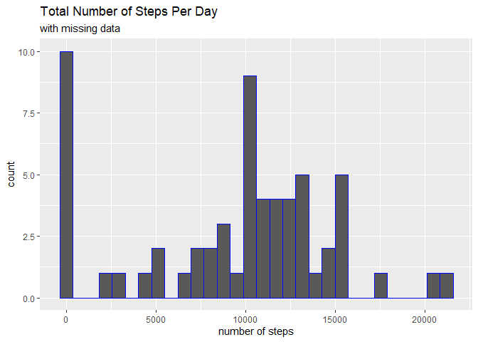

```r
p1 <- ggplot(steps_per_day,aes(steps_day)) +
  geom_histogram(color = "blue") +
  labs(title = "Total Number of Steps Per Day",
       subtitle = "with missing data") +
  xlab("number of steps")

p1
```

#### *Median of total number of steps per day*

```r
med_steps <- median(steps_per_day$steps_day)
```

**Median** of total number of steps per day is **10395**

#### *Mean of total number of steps per day*

```r
aver_steps <- mean(steps_per_day$steps_day)
```

**Mean** of total number of steps per day is **9354.2295082**

## What is the average daily activity pattern?

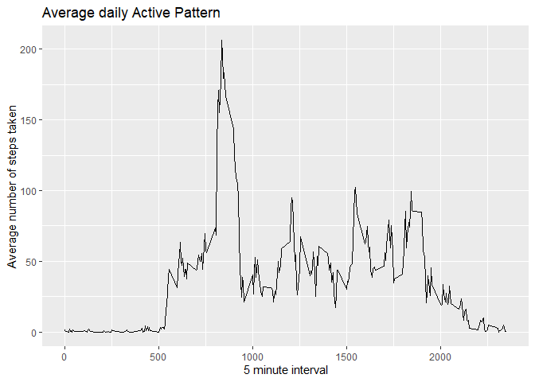

```r
aver_daily_pattern <- activ_monit_dat %>%
  group_by(interval) %>%
  summarise(average_steps_per_interval = mean(steps,na.rm=T))

ggplot(aver_daily_pattern ,aes(x=interval,y=average_steps_per_interval))+
  geom_line() +
  labs(title = "Average daily Active Pattern") +
  xlab("5 minute interval") +
  ylab("Average number of steps taken")
```

```r
max_pat_n_steps <- aver_daily_pattern %>%
  filter(average_steps_per_interval == max(average_steps_per_interval)) %>% select(interval)
```

The 5-minute interval which contains the maximum number is 835

## Imputing missing values

```r
missing = sum(!complete.cases(activ_monit_dat))
```

Total number of **missing values** in the dataset is **2304**

*replace na values in steps variable by the mean of total steps* *and store this new complete dataset in activ_complete dataframe*

```r
activ_complete <- activ_monit_dat %>%
  mutate(steps = replace_na(steps,mean(steps,na.rm = TRUE)))
```

*Check if there are any missing values left in steps variable, as well as in interval variable*

```r
sum(is.na(activ_complete$steps))
```

```
## [1] 0
```

```r
sum(is.na(activ_complete$interval))
```

```
## [1] 0
```

*Aggregate complete dataset to daily*

```r
steps_complete <- activ_complete %>%
  group_by(date) %>%
  summarise(steps_day = sum(steps,na.rm = T))
```

*mean and median calculation for complete dataset*

```r
average_steps_complete <- round(mean(steps_complete$steps_day),1)
med_steps_complete <- round(median(steps_complete$steps_day),1)
```

Complete dataset **mean** value is **10766.2** and **median** **10766.2**. It can be seen that median and mean have the same value, denoting that by replace missing values with the mean, distribution approximates normal distribution, compared to the raw dataset.

*Data distribution of the total number of steps taken each day on a histogram using complete dataset*

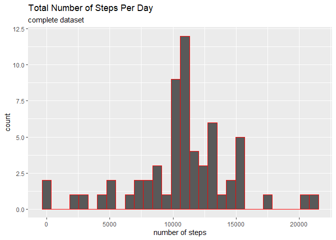

```r
p2 <- ggplot(steps_complete,aes(steps_day)) +
  geom_histogram(color = "red") +
  labs(title = "Total Number of Steps Per Day",
       subtitle = "complete dataset") +
  xlab("number of steps")

p2
```

*comparison of steps taken per day distributions (dataset with missing values, complete dataset). Histograms created with ggplot as well as cowplot packages*

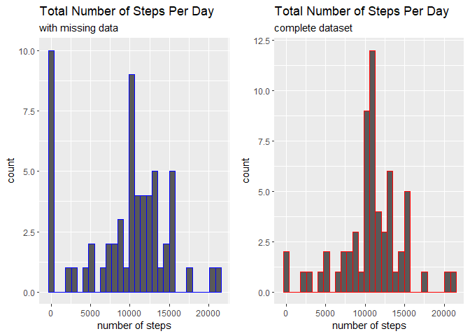

```r
library(cowplot)
plot_grid(p1,p2, ncol = 2)
```

## Are there differences in activity patterns between weekdays and weekends?

```r
library(lubridate)
activity_complete_steps <- activ_complete %>%
  mutate(dayofweek = wday(date),
         weekends = ifelse(dayofweek>=6,"weekend","weekday"),
         weekends = as.factor(weekends))

head(steps_complete)
```

```
## # A tibble: 6 × 2
##   date       steps_day
##   <date>         <dbl>
## 1 2012-10-01    10766.
## 2 2012-10-02      126
## 3 2012-10-03    11352
## 4 2012-10-04    12116
## 5 2012-10-05    13294
## 6 2012-10-06    15420
```

```r
activity_complete_per_interval <- activity_complete_steps %>%
  group_by(interval,weekends) %>%
  summarise(steps_5min = mean(steps))
```

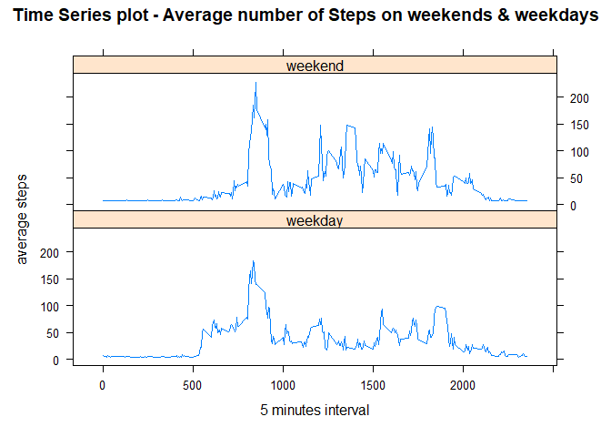

```r
library(lattice)

xyplot(steps_5min~interval | weekends,data=activity_complete_per_interval,
       type="l",
       layout = c(1,2), ylab = "average steps",
       xlab = "5 minutes interval",
       main = "Time Series plot - Average number of Steps on weekends & weekdays")
```